# Working with spatial data in R

Dr. Emily Burchfield

# Objectives

- Learn how R opens, stores, and organizes shapefiles.
- Learn how R handles projection.
- Learn how to create shapefiles in R.

# Pre-lab assignment

- Read the RSpatial chapter on [vector data](http://rspatial.org/spatial/rst/3-vectordata.html).
- If you’re unfamliar with projection, you should also look at the RSpatial chapter on [projection](http://rspatial.org/spatial/rst/6-crs.html). Even if you’re familiar with projection, you may want to review this chapter as it addresses projection in `R`.

# My assumptions

- I’m going to assume you’ve worked with spatial data before and know the difference between points, lines, polygons, and rasters. I’ll also assume you have already learned about the basics of (re)projection in your Intro to GIS course.
- Just a head’s up - a new `sf` package is in the works that will likely change the way we work with spatial data in `R`. It’s brand spanking new, so most of the packages that have been built for spatial data still only work with `sp` objects, which are the focus of this tutorial. Just keep in mind that in the future, these packages may switch to `sf`. More info [here](https://github.com/r-spatial/sf).

# base `R`

All new packages and functions this week, so the base `R` we’ve covered to date should be sufficient!

# Set up

Hooray! We’ve finally made it to spatial data! Well, actually nearly all of the data we’ve already played with is spatial, it just did not contain the coordinate and projection information required to make maps and conduct spatial analyses. This tutorial will focus on giving you the tools required to import, project, and create spatial datasets. There are three main packages used by the `R` community to bring spatial data into `R`. These are:

- `sp`
- `rgdal`
- Our friend the `tidyverse`

Make sure you have these packages installed on your machine.

```r
library(sp)
library(rgdal)
library(tidyverse)
```

# Spatial *objects* in `R`

`sp` is the mama-package of all the spatial packages. You can look through the [`sp` documentation](https://cran.r-project.org/web/packages/sp/vignettes/intro_sp.pdf) to get a sense of all the things you can do with this powerful package. The team behind the `sp` package created a set of new data classes that integrate our best friend the `data.frame` with some friends who at times can be very difficult to hang out with: point, polygon, and raster. These new data classes include the following:

```r
getClass("Spatial")
```

```
## Class "Spatial" [package "sp"]
##
## Slots:
##
## Name:         bbox proj4string
## Class:      matrix         CRS
##
## Known Subclasses:
## Class "SpatialPoints", directly
## Class "SpatialMultiPoints", directly
## Class "SpatialGrid", directly
## Class "SpatialLines", directly
## Class "SpatialPolygons", directly
## Class "SpatialPointsDataFrame", by class "SpatialPoints", distance 2
## Class "SpatialPixels", by class "SpatialPoints", distance 2
## Class "SpatialMultiPointsDataFrame", by class "SpatialMultiPoints", distance 2
## Class "SpatialGridDataFrame", by class "SpatialGrid", distance 2
## Class "SpatialLinesDataFrame", by class "SpatialLines", distance 2
## Class "SpatialPixelsDataFrame", by class "SpatialPoints", distance 3
## Class "SpatialPolygonsDataFrame", by class "SpatialPolygons", distance 2
```

The sub-classes followed by `DataFrame` like `SpatialPointsDataFrame`, include additional attributes in the form of a `data.frame`. For example, if you have a `SpatialPolygon` object of US Census blocks, then this object would *only* include the spatial information required to plot the Census block polygons. With a `SpatialPolygonDataFrame`, you can store this spatial information *and* additional data such as population, race, and income associated with each polygon. This may seem trivial, but, as I’ll show you below, this makes for an incredibly powerful way to organize, visualize, and analyze spatial data. You know me, I like data, so in this class, our spatial objects will almost always come in the `DataFrame` flavor, i.e. with additional attributes attached to the spatial object. Since you guys are now experts on `data.frame` wrangling, this should come as good news![^1]

Did you notice I referred to our new `sp` datasets as *objects*? This is important. In the programming world, an object stores functions and variables relevant only to that object. Huh? For example, we could create a `vehicle` object and assign it a number of attributes that are only relevant to vehicles, i.e. `numberofwheels`, `color`, `weight`, etc. We could also build functions associated with that object, i.e. `compute_mileage()`, `enter_Batman_mode()`, etc. We can bundle all of these object-specific attributes and functions in our `vehicle` object. In the programming world, this is known as object-oriented programming and it is very powerful.[^2]

Our `Spatial` objects have a series of attributes that describe things specific to spatial data such projections and bounding boxes. Let’s say I have loaded a shapefile in `R` and called the new variable that stores this shapefile `states`. I’ll show you how to load shapefiles below. For now, let’s just focus on how `R` organizes the information stored in a shapefile. Let’s start by looking at the `class` of the shapefile object:

[output not shown]

```r
class(states)
```

```
## [1] "SpatialPolygonsDataFrame"
## attr(,"package")
## [1] "sp"
```

Excellent. We confirmed that `states` is, in fact, a spatial object. More precisely, it is a `SpatialPolygonsDataFrame.` Remember, this means that there is a `data.frame` with more info hiding somewhere in this object. Because this is an *object*, it is organized differently than a classic `data.frame` whose variables can be accessed using `$`. In `R`, objects contain slots, which store different types of information or even functions specific to the object. We access different slots using the `@` symbol. Let’s look at some of the slots stored in our `states` object. We can access the actual data (or, in ArcGIS speak, the attribute table) using `@data`:

```r
states@data
```

```
##              STATE_NAME DRAWSEQ STATE_FIPS         SUB_REGION STATE_ABBR
## 0                Hawaii       1         15            Pacific         HI
## 1            Washington       2         53            Pacific         WA
## 2               Montana       3         30           Mountain         MT
## 3                 Maine       4         23        New England         ME
## 4          North Dakota       5         38 West North Central         ND
## 5          South Dakota       6         46 West North Central         SD
## 6               Wyoming       7         56           Mountain         WY
## 7             Wisconsin       8         55 East North Central         WI
## 8                 Idaho       9         16           Mountain         ID
## 9               Vermont      10         50        New England         VT
## 10            Minnesota      11         27 West North Central         MN
## 11               Oregon      12         41            Pacific         OR
## 12        New Hampshire      13         33        New England         NH
## 13                 Iowa      14         19 West North Central         IA
```

[output cut: 37 more lines]

Our data! In `data.frame` form. If you don’t believe me, `class(states@data)` proves that a real live `data.frame` is stored in our spatial object. All of our magical `dplyr` tools apply… want to know how many states are in each sub-region?

```r
states@data %>%
  group_by(SUB_REGION) %>%
  summarize(n_county = n())
```

```
## # A tibble: 9 x 2
##   SUB_REGION         n_county
##   <fctr>                <int>
## 1 East North Central        5
## 2 East South Central        4
## 3 Middle Atlantic           3
## 4 Mountain                  8
## 5 New England               6
## 6 Pacific                   5
## 7 South Atlantic            9
## 8 West North Central        7
## 9 West South Central        4
```

Is your mind blown? Tears streaming down your face? Aren’t you glad you invested all that time in learning about `data.frames` and the `dplyr`? Notice, however, that the output of this `dplyr`ing is a `data.frame`, not a `sp` object. To keep the subset and cleaned shapefile in shapefile form, we have to use a different package called, unsurprisingly, `spdplyr`, which you’ll learn about in another tutorial.

Let’s take a peak at the other info stored in our `states` object. We can also access information about the bounding box of the spatial object:

```r
states@bbox
```

```
##          min       max
## x -178.21760 -66.96927
## y   18.92179  71.40624
```

This is a matrix of bounding box coordinates with column names `c(min,max)` with the first row showing the longitude (x-axis) and the second row showing the latitude (y-axis).

We can also access projection information:

```r
states@proj4string
```

```
## CRS arguments:
##  +proj=longlat +datum=NAD83 +no_defs +ellps=GRS80 +towgs84=0,0,0
```

This slot holds a string that describes the projection of the dataset. This string should be in a `PROJ.4` format.[^3] Wait, what? Hang on, I’ll go through the projection stuff in more detail below.

Together, these slots form a spatial object that we can plot. For now, we will use base `R` to plot this object, but in a future class we’ll learn about more sophisticated mapping tools.

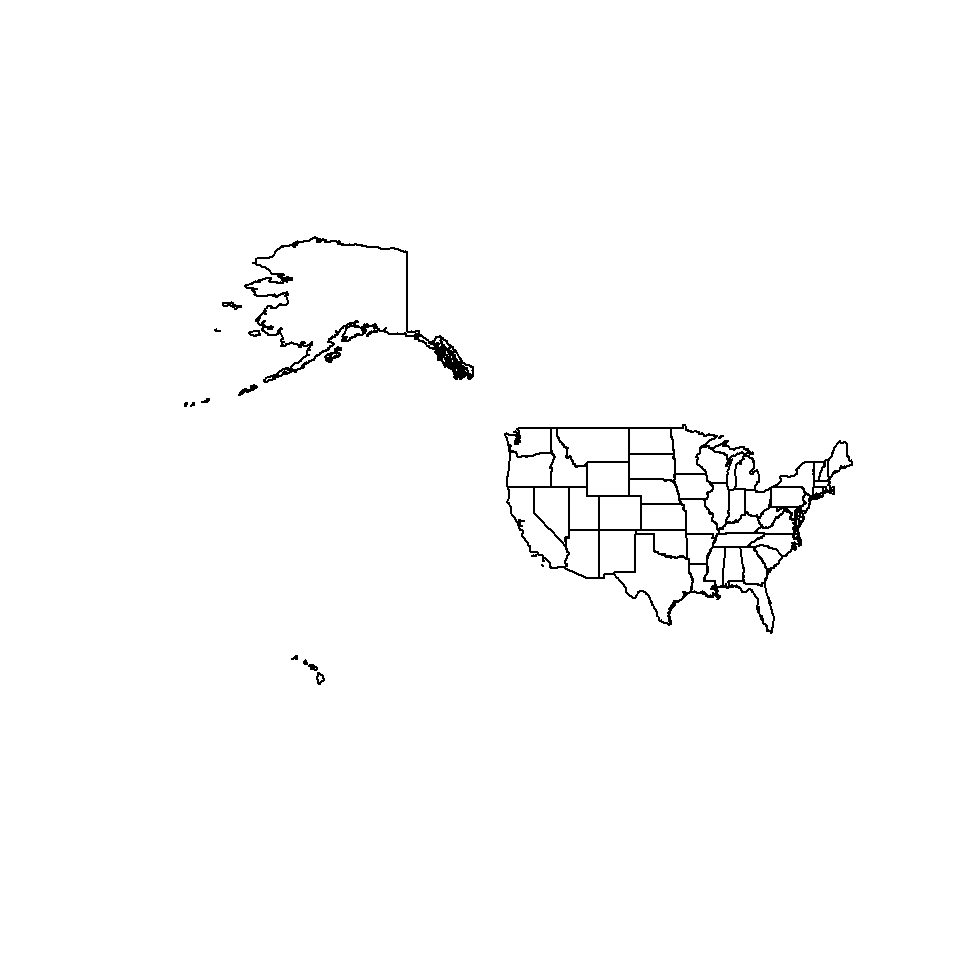

```r
plot(states)
```

Now that you understand how a spatial object is structured and its slots are accessed, let’s move on to loading different types of spatial data into `R`.

# Loading existing shapefiles into `R`

If you’re like me, you have folders full of shapefiles. A single shapefile is often split into many files (e.g. `.cpg`, `.dbf`, `.prj`, etc.), the most important of which is the sacred `.SHP` file. To get all of this info into an organized spatial object in `R` is easy, and in fact, as is often the case in `R`, there are multiple packages and functions that will do this for you. Today, we’ll learn how to use the `rgdal` package to load a shapefile:

```r
library(rgdal)
states <- readOGR(dsn = "./data/states.shp")
summary(states)
```

```
## Object of class SpatialPolygonsDataFrame
## Coordinates:
##          min       max
## x -178.21760 -66.96927
## y   18.92179  71.40624
## Is projected: FALSE
## proj4string :
## [+proj=longlat +datum=NAD83 +no_defs +ellps=GRS80 +towgs84=0,0,0]
## Data attributes:
##       STATE_NAME    DRAWSEQ       STATE_FIPS              SUB_REGION
##  Alabama   : 1   Min.   : 1.0   01     : 1   South Atlantic    : 9
##  Alaska    : 1   1st Qu.:13.5   02     : 1   Mountain          : 8
##  Arizona   : 1   Median :26.0   04     : 1   West North Central: 7
##  Arkansas  : 1   Mean   :26.0   05     : 1   New England       : 6
##  California: 1   3rd Qu.:38.5   06     : 1   East North Central: 5
##  Colorado  : 1   Max.   :51.0   08     : 1   Pacific           : 5
##  (Other)   :45                  (Other):45   (Other)           :11
##    STATE_ABBR
##  AK     : 1
##  AL     : 1
##  AR     : 1
##  AZ     : 1
##  CA     : 1
##  CO     : 1
##  (Other):45
```

The `dsn` argument is simply the path to the shapefile you want to open in `R`. The `summary()` of the shapefile provides some important information. I can immediately see that `R` has read my shapefile in as a `SpatialPolygonsDataFrame`. I can see the bounding box under the `Coordinates` heading. I see that my data is *not* projected (`Is projected: FALSE`) and the `proj4string` string that gives me more information about the data’s coordinate reference system. I can also see the data attributes stored in the `@data` part of the object and some descriptive stats about each variable. Nifty.

# Projection

People tend to hate projections[^4] and generally don’t understand them very well. It is, however, VERY important that you project your data correctly. If you fail to do this, it’s highly likely that your spatial analyses will be wrong. So let’s learn how this stuff works once and for all.

Maps tend to be two-dimensional; the Earth is not. A *coordinate system* is a way to locate everything on Earth’s surface in x and y space. The way we portray [(pseudo-)](https://www.scientificamerican.com/article/earth-is-not-round/)spherical Earth on a flat surface is by using a *projection*. Each projection is associated with a particular coordinate system. There are a bazillion coordinate systems, and each coordination system comes with strong assumptions and distortions (and [fan-base](https://xkcd.com/977/)):

- Geographic Coordinate System (GCS): good ol’ latitude and longitude (degrees, minutes, seconds); we think of data in GCS as *unprojected* (if this doesn’t make sense to you, review the tutorial I’ve made exclusively on projection);
- Universal Transverse Mercator (UTM): lots of zones to choose from, Utah sits in `12N`;
- State Plane Coordinate System: some states have their own systems, i.e. North Carolina Coordinate System
- National systems: If working in another country, check out country-specific projections. Kandawala Sri Lanka Grid anyone?

Each coordinate system is tied to a *datum*. This is essentially a reference point, the starting point from which coordinates are measured (i.e. lat and lon are based on the equator and prime meridian). In `R` we can access the projection information for a `Spatial` object using the `proj4string` attribute of the object:

```r
states@proj4string
```

```
## CRS arguments:
##  +proj=longlat +datum=NAD83 +no_defs +ellps=GRS80 +towgs84=0,0,0
```

```r
states <- spTransform(states, CRS("+proj=aea +lat_1=29.5 +lat_2=45.5 +lat_0=37.5 +lon_0=-96 +x_0=0 +y_0=0 +ellps=GRS80 +datum=NAD83 +units=m +no_defs"))
```

I got that crazy long string by searching for the projection on spatialreference.org and clicking the [Proj4](http://spatialreference.org/ref/esri/usa-contiguous-albers-equal-area-conic/proj4/) link. `R` expects projection information to come in this `proj4` format.

If you happen to have a shapefile that has an undefined projection in `R`, but you happen to know what projection the data is in, you can set the projection as follows:

```r
shp <- readOGR("./path/to/shp.shp")
projection(shp) <- CRS("+proj=aea +lat_1=29.5 +lat_2=45.5 +lat_0=37.5 +lon_0=-96 +x_0=0 +y_0=0 +ellps=GRS80 +datum=NAD83 +units=m +no_defs")
```

Finally, don’t forget that the map projection you use strongly impacts the way you visualize and analyze your data (see [here](https://source.opennews.org/articles/choosing-right-map-projection/) or [here](https://www.economist.com/blogs/dailychart/2010/11/cartography))).

# Building new shapefiles in `R`

## Points

Let’s say I’m a volcanologist and I find a really cool dataset describing all eruptions on Earth during the Holocene.[^5] The data is stored in a `.csv` document. We now know how to open the `.csv` in `R` and inspect its contents:

```r
volcano <- read.csv('./data/volcano.csv')
glimpse(volcano)
```

```
## Observations: 1,496
## Variables: 13
## $ ï..Volcano.Number    <int> 210010, 210020, 210030, 210040, 211001, 2...
## $ Volcano.Name         <fctr> West Eifel Volcanic Field, Chaine des Pu...
## $ Country              <fctr> Germany, France, Spain, Spain, Italy, It...
## $ Primary.Volcano.Type <fctr> Maar(s), Lava dome(s), Pyroclastic cone(...
## $ Activity.Evidence    <fctr> Eruption Dated, Eruption Dated, Evidence...
## $ Last.Known.Eruption  <fctr> 8300 BCE, 4040 BCE, Unknown, 3600 BCE, 1...
## $ Region               <fctr> Mediterranean and Western Asia, Mediterr...
## $ Subregion            <fctr> Western Europe, Western Europe, Western ...
## $ Latitude             <dbl> 50.170, 45.775, 42.170, 38.870, 43.250, 4...
## $ Longitude            <dbl> 6.850, 2.970, 2.530, -4.020, 10.870, 11.9...
## $ Elevation..m.        <int> 600, 1464, 893, 1117, 500, 800, 949, 458,...
## $ Dominant.Rock.Type   <fctr> Foidite, Basalt / Picro-Basalt, Trachyba...
## $ Tectonic.Setting     <fctr> Rift zone / Continental crust (>25 km), ...
```

But we’re not here to learn how to work with `.csv` data… we have now graduated to spatial data! So how do we turn our `.csv` into a `SpatialPointsDataFrame` (`SpatialPoints` because we’re dealing with coordinates of eruptions and `DataFrame` because there are more attributes than these coordinates, like `Volcano.Name` and `Country`)?

[figure not shown]

```r
prj <- CRS("+proj=longlat +ellps=WGS84 +datum=WGS84 +no_defs")

select <- dplyr::select #this tells R to use the select() function from the dplyr package, not the select function stored in some of the spatial packages
coords <- volcano %>% select(Longitude, Latitude)
volcano_pt <- SpatialPointsDataFrame(coords = coords, data = volcano, proj4string = prj)
plot(volcano_pt)
```

Notice here that I had to define the projection of my dataset using the `prj` variable. I make the `prj` variable a `CRS` object using the `CRS()` function. This essentially smooshes the long projection string into a format that `R` likes. Be sure you’ve formatted your projection data using the `CRS()` function when you’re creating shapefiles. I have to create a `coords` variable that stores the longitude and latitude for my point dataset. I used `dplyr` to select these two columns from the full `volcano` dataset. Then we mix it all together to bake a beautiful volcanic spatial cake using the `SpatialPointsDataFrame()` function. To learn more about this function, you know what to do (`?SpatialPointsDataFrame`).

Ohhh how I want to transform this ugly base `R` plot into something better. That’s coming. For now, here’s a plot with base `R` and some data from the `maptools` package:

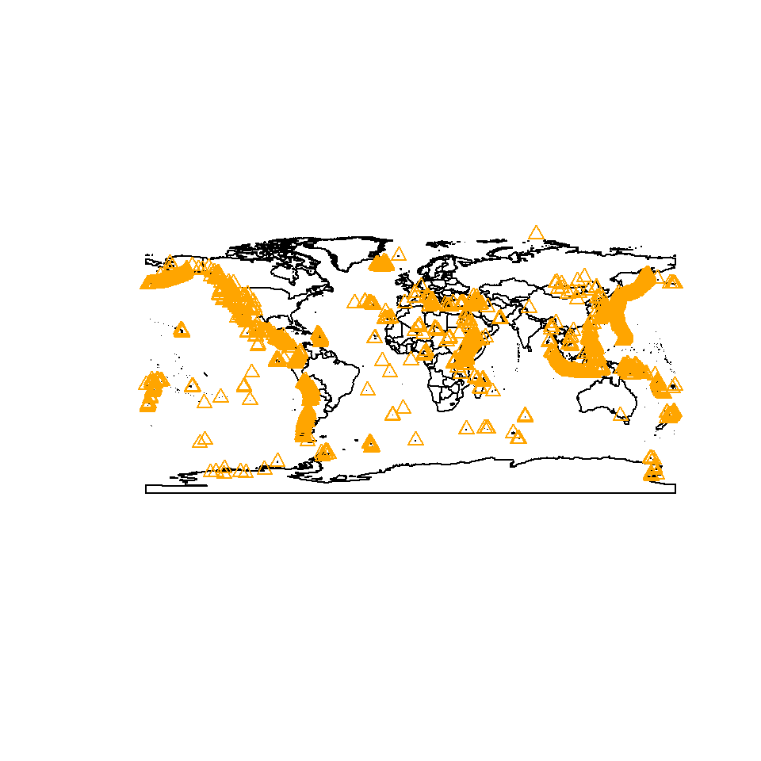

```r
library(maptools)
data(wrld_simpl)
plot(wrld_simpl)
plot(volcano_pt, add=T, col='orange', pch=2)
```

Note the `add=T` argument. This lets you add multiple layers to one plot. Could be useful for the homework! :)

## Polygons

Most of the polygon data I work with has already been built by someone else, so I don’t often build polygons from scratch. I can, however, think of many, many instances when this would be a very useful skill to master. I found a fantastic tutorial [HERE](http://www.nickeubank.com/wp-content/uploads/2015/10/RGIS1_SpatialDataTypes_part1_vectorData.html) on creating `SpatialPolygon` objects. I’ll summarize it below.

Our ultimate objective is to have a complete `SpatialPolygons` object. To do this in `R`, we have to build each individual polygon and bundle them all together. Let’s start by building a set of simple polygons describing the outline of the main part of a house and of the roof (in this example, the coordinates are arbitrary; in the real world, you’d have actual coordinates). The `rbind()` function pulls together each set of coordinates (i.e. `c(1,1)`) and binds them together in separate rows to create a mini-matrix of coordinates. The `hole=T` option in the `house2.door` variable is a cool option that tells `R` to view that polygon as detracting from the area of the larger polygon it is a part of, i.e. when you compute the surface area of House 2, don’t include the door.

```r
house1.building <- Polygon(rbind(c(1, 1), c(2, 1), c(2, 0), c(1, 0)))

house1.roof <- Polygon(rbind(c(1, 1), c(1.5, 2), c(2, 1)))

house2.building <- Polygon(rbind(c(3, 1), c(4, 1), c(4, 0), c(3, 0)))

house2.roof <- Polygon(rbind(c(3, 1), c(3.5, 2), c(4, 1)))

house2.door <- Polygon(rbind(c(3.25, 0.75), c(3.75, 0.75), c(3.75, 0), c(3.25,
    0)), hole=T)
```

Now, let’s bind the individual `Polygon` objects into a `Polygons` object for House 1 and House 2.

```r
h1 <- Polygons(list(house1.building, house1.roof), "H1")
h2 <- Polygons(list(house2.building, house2.roof, house2.door), "H2")
```

And finally, let’s bundle everything into a `SpatialPolygon` and plot our beautiful houses:

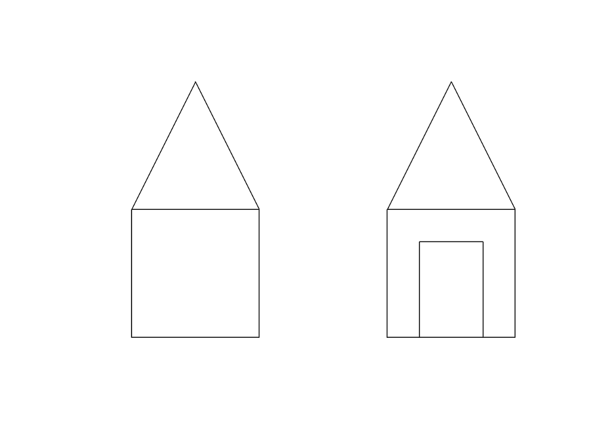

```r
# create spatial polygons object from lists A SpatialPolygons is like a
# shapefile or layer.
houses <- SpatialPolygons(list(h1, h2))
plot(houses)
```

`SpatialPolygons` are cool and all, but `SpatialPolygonsDataFrames` are much cooler. How do we add data to our new `SpatialPolygon`? First let’s make some attributes:

```r
attr <- data.frame(attr1=c(0,100), attr2 = c(7, 24), row.names = c("H1", "H2"))
colnames(attr) <- c("Accessibility", "Party duration")
attr
```

```
##    Accessibility Party duration
## H1             0              7
## H2           100             24
```

Now to make our `SPDF`. We’ll learn more about `spplot()`, the plotting tool in the `sp` package in a later lesson:

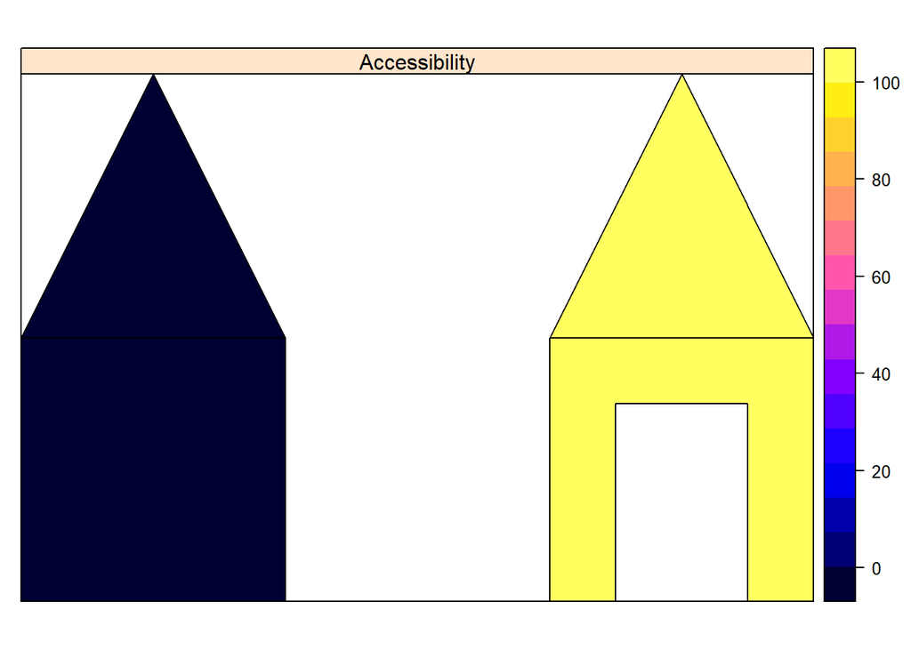

```r
houses.df <- SpatialPolygonsDataFrame(houses, attr)
spplot(houses.df)
```

Conclusion? If you want to have a party, make sure your house has a door.

You can apply the same basic principles to make a `SpatialLines` object.

# Writing out spatial data

For shapefiles, I recommend using the `rgdal` package. Here, I’m writing out the `houses.df` `SpatialPolygonDataFrame` we built above:

```r
writeOGR(obj = houses.df, dsn="./data/house.shp", layer="house", driver="ESRI Shapefile", overwrite=T)
```

The `writeOGR()` function requires you input the name of the object you want to save (`obj`), the destination for the object (`dsn`), the layer name you want to give the object (`layer`) and the driver, or data type, you want to write out (`driver`). I’ve written out a classic `ESRI Shapefile` but there are lots of other drivers you can use found [here](http://www.gdal.org/ogr_formats.html).

There’s lots more information on writing out geospatial data in `R` [here](http://www.rspatial.org/spatial/rst/5-files.html).

# Additional Resources

- Chapter 2 of *Applied Spatial Data Analysis with R* (reference on Canvas More Resources page). The authors of the book are also the authors of the `sp` package.
- This [tutorial](http://data-analytics.net/cep/Schedule_files/geospatial.html) created by David Beskow.
- DataCamp’s [Working with Geospatial Data in R](https://www.datacamp.com/courses/working-with-geospatial-data-in-r) tutorial created by Charlotte Wickham (I believe she’s the sister of Hadley Wickham of tidyverse family, pretty prolific family!).
- More information on [opening spatial data in R](http://neondataskills.org/R/open-shapefiles-in-R/)
- For more in projection in R, see [this tutorial](http://neondataskills.org/R/vector-data-reproject-crs-R/).
- For more on transforming csv files into shapefiles, see [this tutorial](http://neondataskills.org/R/csv-to-shapefile-R/)
[^1]: I know, I know… you’re dying to know if this means we can use the `dplyr` with spatial data!? YES WE CAN! We’ll get there.
[^2]: If you’re interested in how spatial objects are built in `R`, [check this out](http://www.cyclismo.org/tutorial/R/s4Classes.html)
[^3]: Check out [this website](http://proj4.org/projections/index.html) for allllll the info you could ever want about `proj.4` strings.
[^4]: The only person who was ever pumped about projections was an old Flemish dude named [Mercator.](https://en.wikipedia.org/wiki/Gerardus_Mercator)
[^5]: Volcanologists rejoice! This dataset exists and I encourage you to use it in your class project.